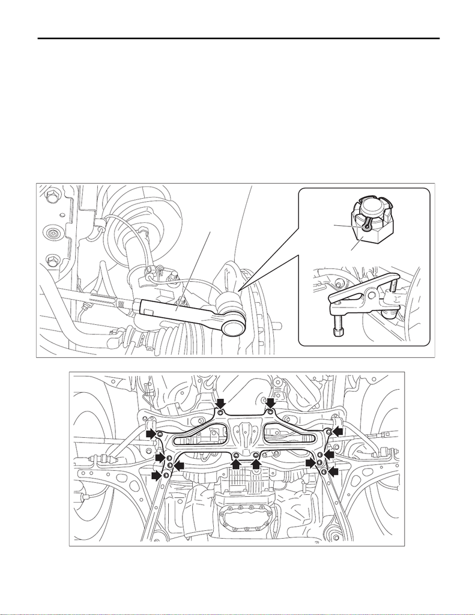

PS-30

Steering Gearbox

POWER ASSISTED SYSTEM (POWER STEERING)

6. Steering Gearbox

A: REMOVAL

1) Lift up the vehicle, and then remove the front wheels.

2) Remove the under cover - front. <Ref. to EI-21, REMOVAL, Front Under Cover.>

3) Disconnect the tie-rod end.

(1) Pull out the cotter pin (a).

(2) Remove the castle nut (b).

(3) Using a tie-rod end puller, remove the tie-rod end (c).

CAUTION:

Be careful not to damage the boot of the joint.

Preparation tool:

Tie-rod ball joint puller

4) Remove the bolt, and remove the front crossmember support.

FS-00505

(a)

(b)

(c)

PS-01732

15WRX_STI_US_EN.book 30 ページ ２０１５年２月１３日 金曜日 午前１１時２０分

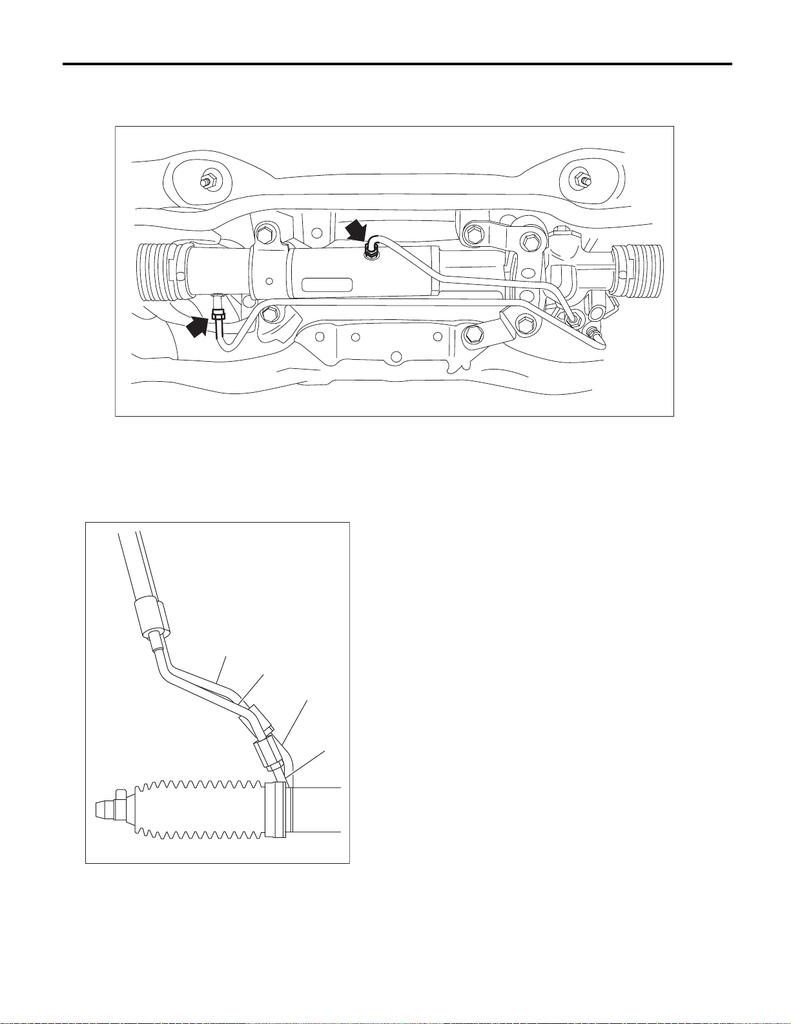

PS-31

Steering Gearbox

POWER ASSISTED SYSTEM (POWER STEERING)

5) Remove the front stabilizer. <Ref. to FS-31, REMOVAL, Front Stabilizer.>

6) Drain the power steering fluid.

(1) Remove the pipe joint of the gearbox, and connect the vinyl hose to the pipe and the joint.

(2) Discharge the fluid by turning the steering wheel fully clockwise and counterclockwise.

(3) Discharge the fluid similarly from other pipes.

7) Remove the universal joint assembly - steering. <Ref. to PS-21, REMOVAL, Universal Joint.>

8) Disconnect the ground cable from battery. <Ref. to NT-5, BATTERY, NOTE, Note.>

9) Disconnect the feed pipe from the pressure hose first, then disconnect the return pipe from the hose - re-

turn.

PS-01754

PS-00538

(4)

(3)

(2)

(1)

(1) Feed pipe

(2) Return pipe

(3) Pressure hose

(4) Hose - return

15WRX_STI_US_EN.book 31 ページ ２０１５年２月１３日 金曜日 午前１１時２０分

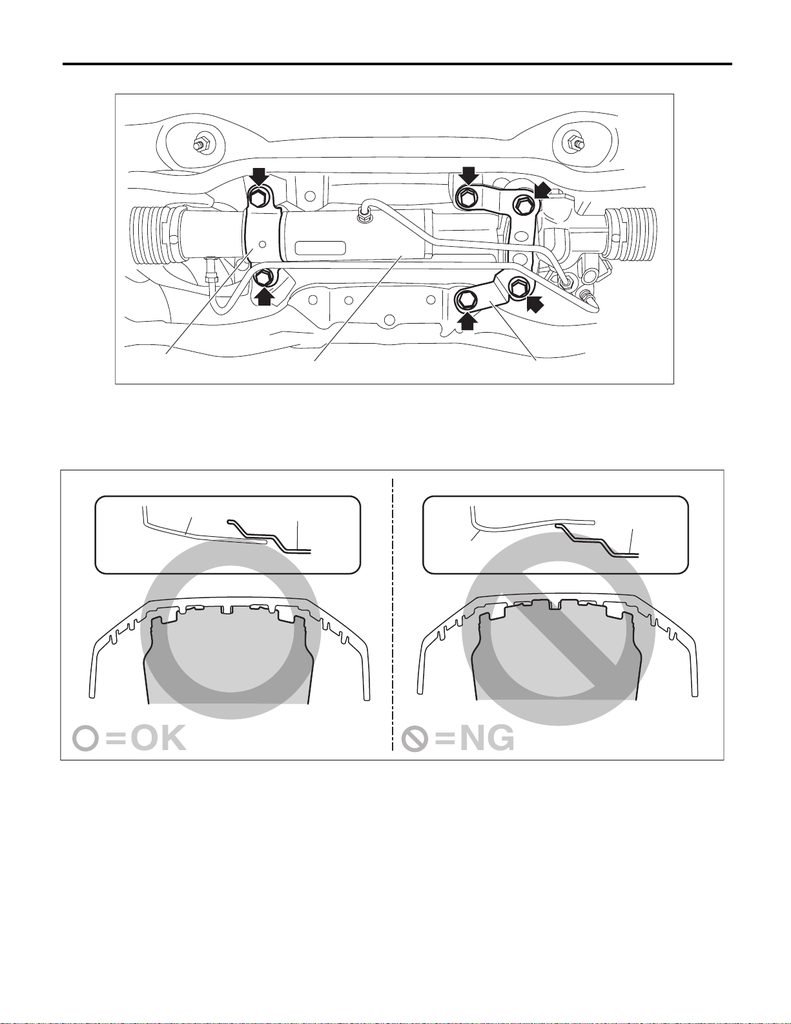

PS-32

Steering Gearbox

POWER ASSISTED SYSTEM (POWER STEERING)

10) Remove the bolts securing the gearbox, and remove the stiffener (a), clamp (b) and gearbox (c).

B: INSTALLATION

CAUTION:

Install the under cover - front so that the front end of the under cover (b) comes inside the bumper

face - front (a).

PS-01755

(b)

(c)

(a)

EI-04291

(b)

(a)

(b)

(a)

15WRX_STI_US_EN.book 32 ページ ２０１５年２月１３日 金曜日 午前１１時２０分

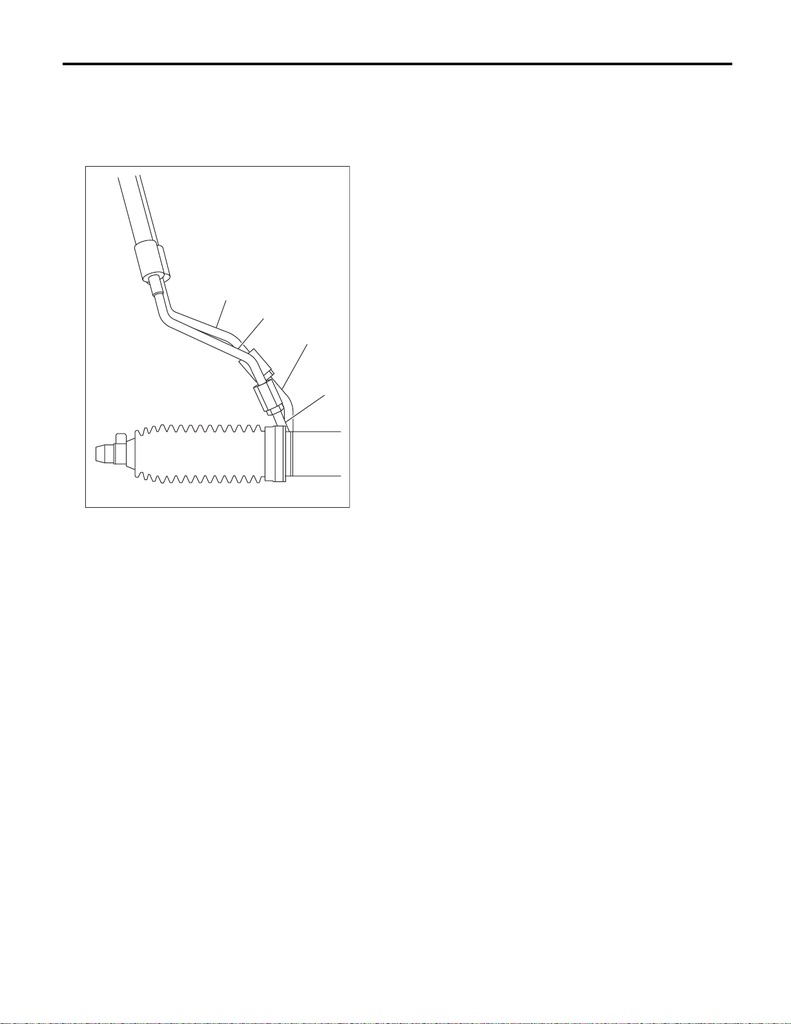

PS-33

Steering Gearbox

POWER ASSISTED SYSTEM (POWER STEERING)

1) Insert the gearbox into crossmember, being careful not to damage gearbox boot.

2) Install the gearbox to the crossmember through the clamp and stiffener.

Tightening torque:

60 N·m (6.1 kgf-m, 44.3 ft-lb)

3) Connect the return pipe to the hose - return and then connect the feed pipe to the pressure hose.

Tightening torque:

15 N·m (1.5 kgf-m, 11.1 ft-lb)

4) Install the universal joint assembly - steering. <Ref. to PS-22, INSTALLATION, Universal Joint.>

PS-00538

(4)

(3)

(2)

(1)

(1) Feed pipe

(2) Return pipe

(3) Pressure hose

(4) Hose - return

15WRX_STI_US_EN.book 33 ページ ２０１５年２月１３日 金曜日 午前１１時２０分

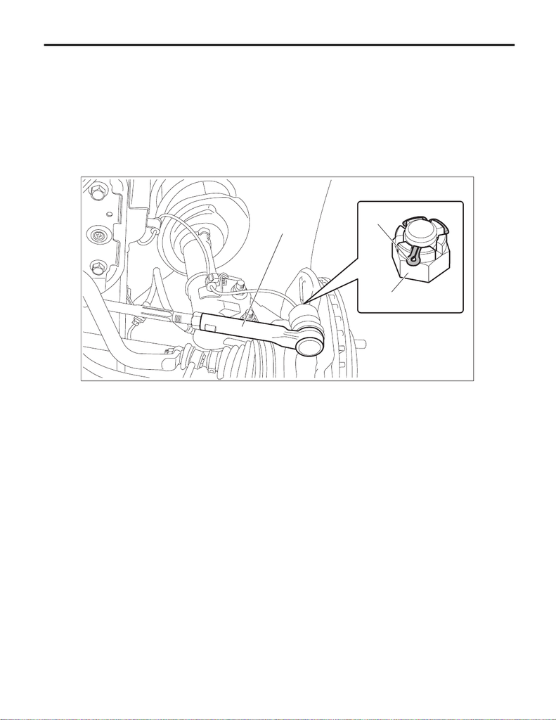

PS-34

Steering Gearbox

POWER ASSISTED SYSTEM (POWER STEERING)

5) Connect the tie-rod ends.

(1) Connect the tie-rod end (a) to the housing assembly - front axle.

(2) Tighten the castle nuts (b) to the specified torque.

CAUTION:

When connecting the tie-rod, do not hit the cap at bottom of tie-rod end with a hammer.

Tightening torque:

27 N·m (2.8 kgf-m, 19.9 ft-lb)

(3) Tighten within the range of 60° so that the cotter pin hole and cutout portion of the castle nut (b) are

aligned.

(4) Insert the cotter pin (c), and bend the tip of the pin to fix it.

6) Install the front stabilizer. <Ref. to FS-31, INSTALLATION, Front Stabilizer.>

7) Install the front crossmember support.

Tightening torque:

Front suspension parts: <Ref. to FS-4, FRONT SUSPENSION, COMPONENT, General Description.>

8) Install the under cover - front. <Ref. to EI-22, INSTALLATION, Front Under Cover.>

9) Install the front wheels.

10) Lower the vehicle.

11) Tighten the wheel nuts to the specified torque.

Tightening torque:

120 N·m (12.2 kgf-m, 88.5 ft-lb)

12) Connect the battery ground terminal. <Ref. to NT-5, BATTERY, NOTE, Note.>

13) Pour fluid into the oil tank, and bleed air. <Ref. to PS-83, Power Steering Fluid.>

14) Check for fluid leaks.

15) Check the fluid level in oil tank.

PS-01325

(a)

(c)

(b)

15WRX_STI_US_EN.book 34 ページ ２０１５年２月１３日 金曜日 午前１１時２０分

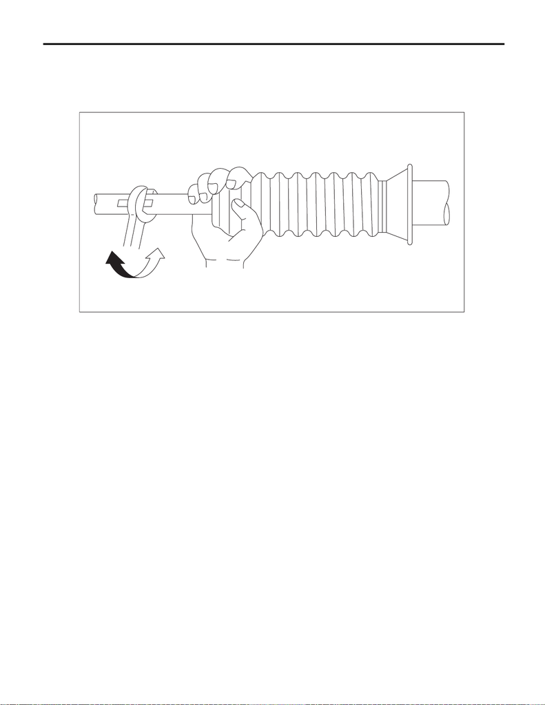

PS-35

Steering Gearbox

POWER ASSISTED SYSTEM (POWER STEERING)

16) Adjust the toe-in and steering angle. <Ref. to FS-17, FRONT WHEEL TOE-IN, ADJUSTMENT, Wheel

Alignment.>

NOTE:

When adjusting toe-in, hold the boot as shown to prevent it from being rotated or twisted. If it becomes twist-

ed, straighten it.

17) Tighten the tie-rod end lock nut.

Tightening torque:

85 N·m (8.7 kgf-m, 62.7 ft-lb)

PS-01343

15WRX_STI_US_EN.book 35 ページ ２０１５年２月１３日 金曜日 午前１１時２０分

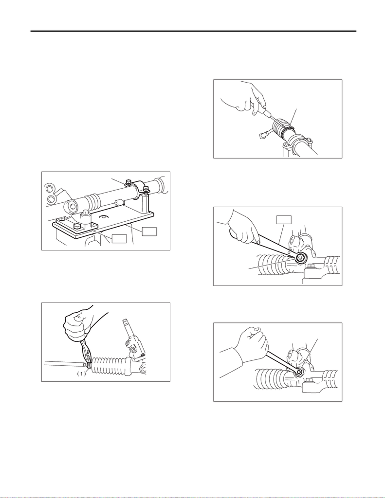

PS-36

Steering Gearbox

POWER ASSISTED SYSTEM (POWER STEERING)

C: DISASSEMBLY

1. RACK HOUSING ASSEMBLY

1) Disconnect the four pipes from gearbox.

NOTE:

clamp plate, as a unit.

2) Secure the gearbox removed from vehicle in a

vise using ST.

CAUTION:

Using the ST, secure the gearbox assembly in a

vise as shown in the figure. Do not secure the

gearbox without this ST.

Preparation tool:

ST1: STAND (926200000)

ST2: BOSS D (34199AG000)

3) Remove the tie-rod end and lock nut from gear-

box.

4) Remove the small clip from the boot using pliers,

and then move the boot to tie-rod end side.

5) Using a flat tip screwdriver, remove the band

from boot.

NOTE:

Replace the boot if there is damage, cracks or de-

terioration.

6) Using the ST, loosen the lock nut.

Preparation tool:

ST: SPANNER (926230000)

7) Tighten the adjusting screw until it can no longer

be tightened.

8) Remove the tie-rod.

9) Loosen the adjusting screw, and remove the

spring and sleeve.

(1) Clamp

(1) Clip

(1)

ST1

ST2

PS-00492

PS-00053

(1) Band

(1) Lock nut

(1) Adjusting screw

PS-00509

(1)

ST

(1)

PS-00494

(1)

PS-00495

15WRX_STI_US_EN.book 36 ページ ２０１５年２月１３日 金曜日 午前１１時２０分

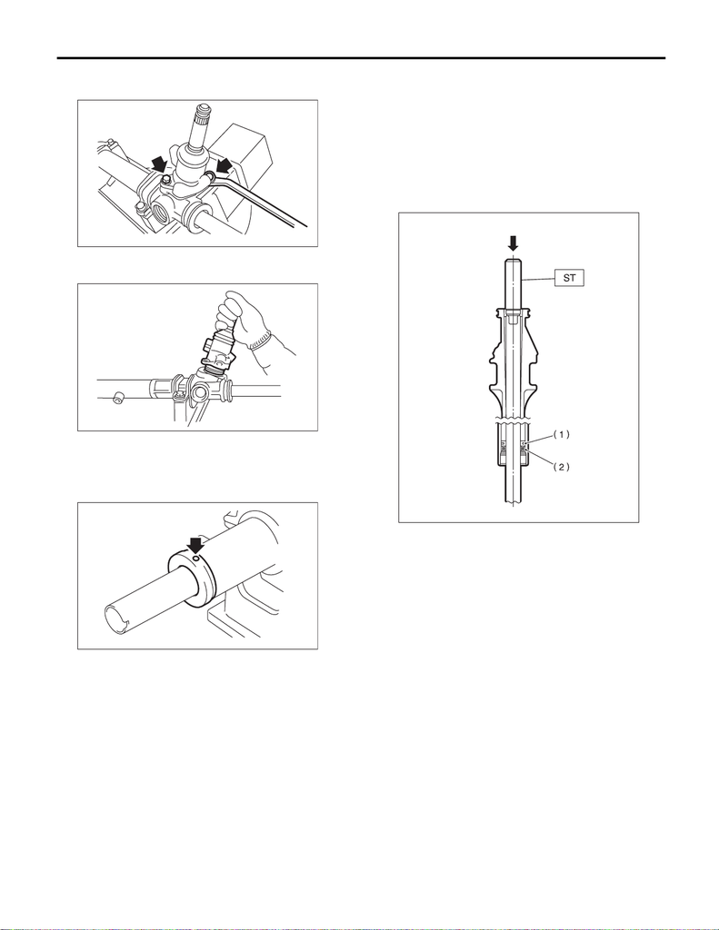

PS-37

Steering Gearbox

POWER ASSISTED SYSTEM (POWER STEERING)

10) Remove the two bolts securing valve assem-

bly.

11) Carefully draw out the input shaft and remove

the valve assembly.

12) Using a drill, release the crimping of holder.

CAUTION:

Make a hole of 2 mm (0.08 in) depth using a drill

with 3 mm (0.12 in) diameter.

13) Remove the holder.

14) Attach the ST on the valve side of rack, and

press out the outer side oil seal and rack while tak-

ing care that the rack and the steering body inner

surface do not come into contact with each other.

Preparation tool:

ST: INSTALLER & REMOVER (34199XA030)

NOTE:

Block the pipe connection of steering body to pre-

vent fluid from flowing out.

PS-00116

PS-00117

PS-00516

(1) Rack piston

(2) Outer side oil seal

PS-00064

15WRX_STI_US_EN.book 37 ページ ２０１５年２月１３日 金曜日 午前１１時２０分

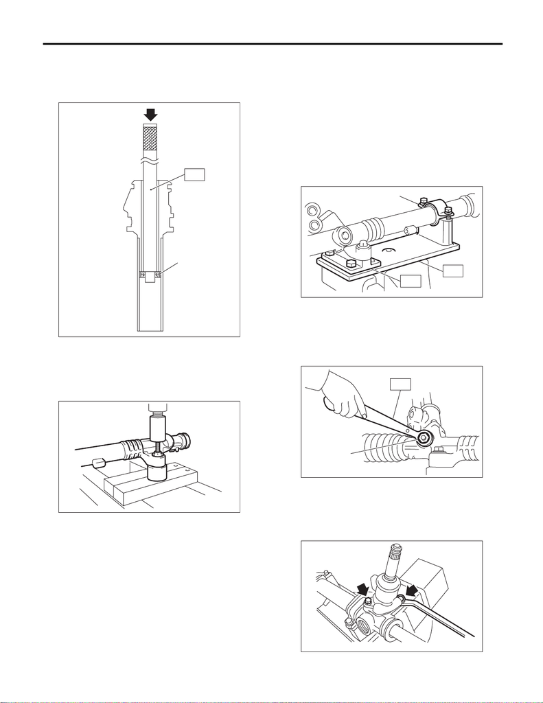

PS-38

Steering Gearbox

POWER ASSISTED SYSTEM (POWER STEERING)

15) Insert the ST from pinion housing side and re-

move the oil seal and back-up ring using a press.

Preparation tool:

ST: OIL SEAL REMOVER (34099PA010)

16) Using a press, remove the bushing of gearbox

installation portion.

2. CONTROL VALVE

1) Disconnect the four pipes from gearbox.

2) Secure the gearbox removed from vehicle in a

vise using ST.

CAUTION:

Using the ST, secure the gearbox assembly in a

vise as shown in the figure. Do not secure the

gearbox without this ST.

Preparation tool:

ST1: STAND (926200000)

ST2: BOSS D (34199AG000)

3) Using the ST, loosen the lock nut.

Preparation tool:

ST: SPANNER (926230000)

4) Loosen the adjusting screw, and remove the

spring and sleeve.

5) Remove the two bolts securing valve assembly.

(1) Press

(2) Oil seal

PS-00138

(2)

(1)

ST

PS-00517

(1) Clamp

(1) Lock nut

(1)

ST1

ST2

PS-00492

ST

(1)

PS-00494

PS-00116

15WRX_STI_US_EN.book 38 ページ ２０１５年２月１３日 金曜日 午前１１時２０分

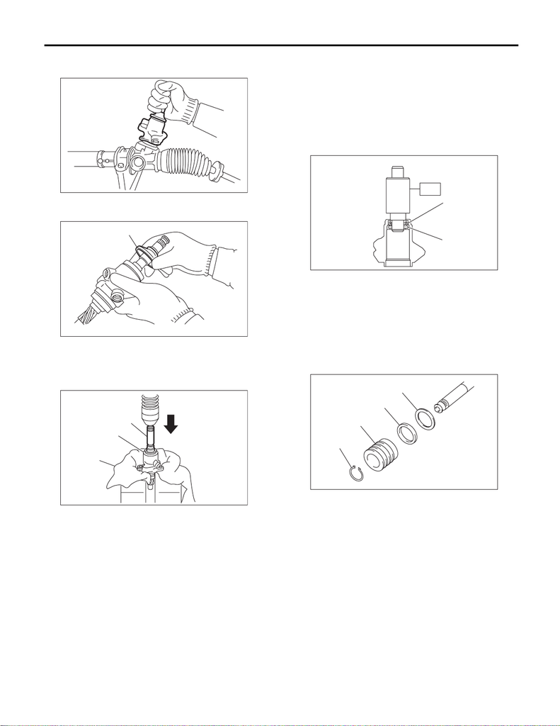

PS-39

Steering Gearbox

POWER ASSISTED SYSTEM (POWER STEERING)

6) Carefully draw out the input shaft and remove

the valve assembly.

7) Put a vinyl tape around the spline portion, and

slide the dust cover to remove.

8) Using a press, remove the pinion & valve as-

sembly from valve housing.

9) Using the ST and a press, remove the bushing

and oil seal from the valve housing.

CAUTION:

• Do not apply a force to the end surface of

valve housing.

• Do not reuse the oil seal after removal.

Preparation tool:

ST: INSTALLER & REMOVER (34199AG090)

10) Using a snap ring pliers, remove the snap ring,

valve, oil seal and back-up washer.

CAUTION:

Be careful not to scratch the pinion and valve

assembly.

(1) Dust cover

(1) Pinion & valve ASSY

(2) Valve housing

(3) Cloth

PS-00143

PS-00144

(1)

(2)

(3)

(1)

PS-00149

(1) Oil seal

(2) Bushing

(1) Snap ring

(2) Valve

(3) Oil seal

(4) Back-up ring

(2)

(1)

ST

PS-00855

PS-00518

(1)

(2)

(3)

(4)

15WRX_STI_US_EN.book 39 ページ ２０１５年２月１３日 金曜日 午前１１時２０分

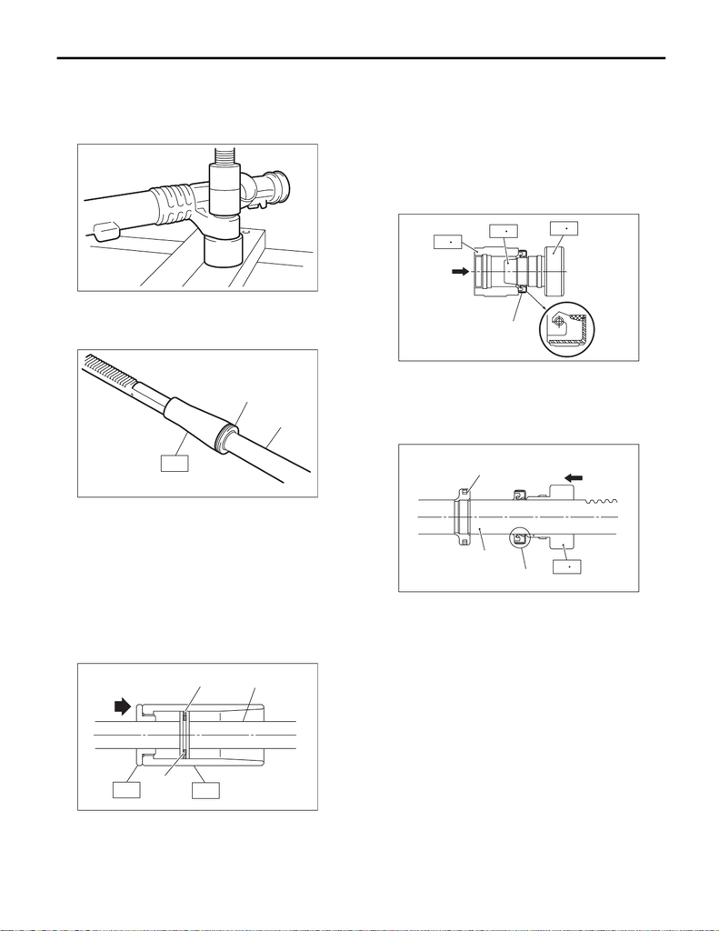

PS-40

Steering Gearbox

POWER ASSISTED SYSTEM (POWER STEERING)

D: ASSEMBLY

1. RACK HOUSING ASSEMBLY

1) Using a press, install the bushing to gearbox in-

stallation portion.

2) Insert the ST to rack.

Preparation tool:

ST: GUIDE (34199AG040)

3) Install the seal ring and O-ring to piston portion

of rack.

4) Using the ST, form the seal ring properly.

Preparation tool:

ST1: FORMER PISTON (34199AG080)

5) Using the ST-A and ST-B, attach the oil seal to

ST-C.

Preparation tool:

ST-A: INSTALLER A (34199FE070)

ST-B: INSTALLER B (34199FE080)

ST-C: INSTALLER C (34199FE090)

NOTE:

Face the oil seal in the direction as shown in the fig-

ure.

6) Insert the ST-C with oil seal assembled from the

gear side of rack. Remove the oil seal from ST-C

near piston, and then remove the ST-C from rack.

(1) Seal ring

(2) Rack

(3) O-ring

(1) Seal ring

(2) Rack

(3) O-ring

PS-00519

PS-01210

ST

(1),(3)

(2)

PS-01211

(2)

(1)

ST1

ST2

(3)

(A) Oil seal

(A) Oil seal

(B) Rack

(C) Piston

ST C

ST B

ST A

(A)

PS-01000

ST C

(A)

(B)

(C)

PS-01001

15WRX_STI_US_EN.book 40 ページ ２０１５年２月１３日 金曜日 午前１１時２０分

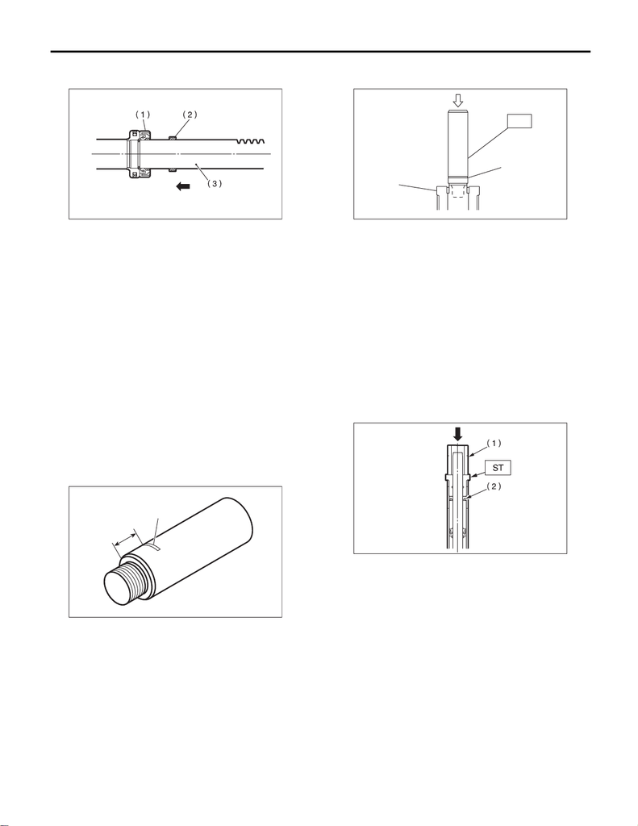

PS-41

Steering Gearbox

POWER ASSISTED SYSTEM (POWER STEERING)

7) Install the back-up ring from the gear side of

rack.

8) Check the threaded end of holder and gearbox

cylinder end for burrs, damage, etc. Correct if

faulty.

9) Apply a coat of grease to the grooves in rack,

sliding surface of sleeve and sealing surface of pis-

ton. Then insert the rack into steering body from

cylinder side.

10) Temporarily tighten a new holder to the gear-

box cylinder.

11) Put a mark at the specified position measured

from the end surface of ST as shown in the figure.

Specified position:

15 mm (0.59 in)

Preparation tool:

ST: INSTALLER & REMOVER (34199XA030)

12) Set the ST to the end of rack.

Preparation tool:

ST: INSTALLER & REMOVER (34199XA030)

13) Using a press, press-fit until the mark on the ST

is aligned with the end surface of the holder.

14) Remove the ST and holder.

15) Insert the outer side oil seal into the rack using

the same procedure as steps 5) and 6).

Preparation tool:

ST-A: INSTALLER A (34199FE070)

ST-B: INSTALLER B (34199FE080)

ST-C: INSTALLER C (34199FE090)

16) Put the ST and pipe through the rack, and

press-fit the outer side oil seal using a press.

Preparation tool:

ST: INSTALLER (34199AG010)

(1) Oil seal

(2) Back-up ring

(3) Rack

(1) 15 mm (0.59 in)

(2) Place a mark

PS-00077

PS-00851

(1)

(2)

(1) Mark

(2) Holder

(1) Pipe

(2) Outer side oil seal

PS-00522

ST

(1)

(2)

PS-00852

15WRX_STI_US_EN.book 41 ページ ２０１５年２月１３日 金曜日 午前１１時２０分

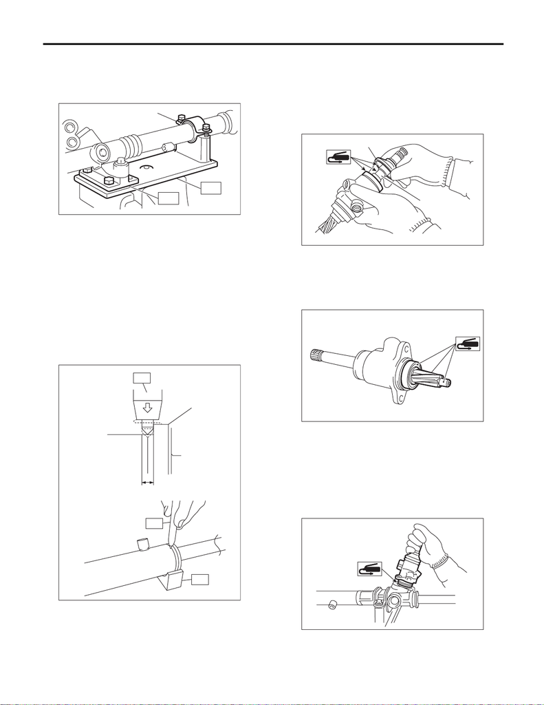

PS-42

Steering Gearbox

POWER ASSISTED SYSTEM (POWER STEERING)

17) Secure the gearbox in a vise using ST.

Preparation tool:

ST1: STAND (926200000)

ST2: BOSS D (34199AG000)

18) Tighten the holder.

Tightening torque:

70 N·m (7.1 kgf-m, 51.6 ft-lb)

19) Using the ST, crimp so that the diameter of

punch hole is 2 — 2.5 mm (0.08 — 0.10 in) and is

aligned to the position of 2 mm (0.08 in) from gear-

box cylinder end surface.

Preparation tool:

ST1: PUNCH HOLDER (34099FA060)

ST2: BASE (34199FE020)

20) Put a vinyl tape around the spline portion and

apply genuine grease to the dust cover and fill it to

the clearance between pinion shaft and housing,

then install the valve assembly.

CAUTION:

Be sure to install the dust cover to groove of

shaft.

21) Apply the genuine grease to the edge and body

of pinion gear and bearing of valve assembly.

22) Apply grease to a new O-ring and attach it to

the valve assembly. Insert the valve assembly into

the given place while facing the rack teeth toward

pinion.

CAUTION:

Check that the needle bearing is not damaged.

Replace with a new steering gearbox if damage

is found.

(1) Clamp

(A) Holder

(B) 2 mm (0.08 in)

(1)

ST1

ST2

PS-00492

(A)

(B)

ST1

ST2

ST1

PS-00859

(1) Dust cover

(2) Groove

PS-01675

(1)

(2)

PS-01674

PS-01673

15WRX_STI_US_EN.book 42 ページ ２０１５年２月１３日 金曜日 午前１１時２０分

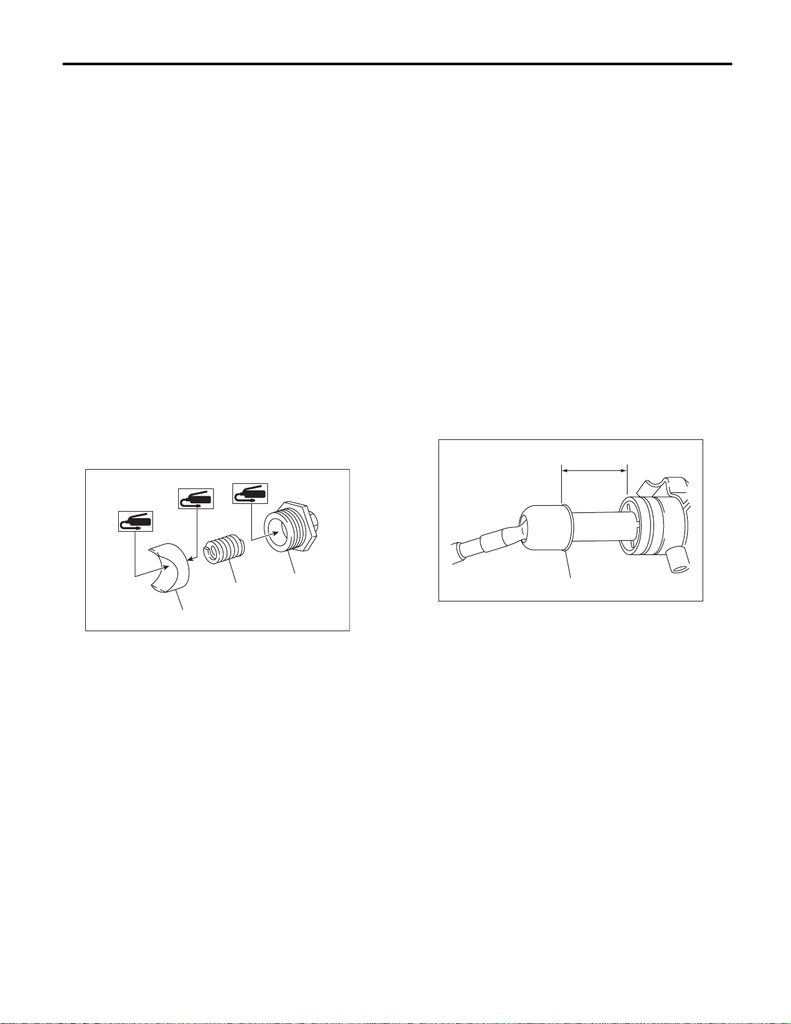

PS-43

Steering Gearbox

POWER ASSISTED SYSTEM (POWER STEERING)

23) Tighten the bolts alternately to secure the valve

assembly.

CAUTION:

Be sure to alternately tighten the bolts.

Tightening torque:

20 N·m (2.0 kgf-m, 14.8 ft-lb)

24) Temporarily tighten the tie-rod to the rack end,

and then operate the rack from lock to lock for two

or three times to make it fit in.

CAUTION:

Operating the rack from lock to lock without in-

stalling tie-rods may damage the oil seal. Al-

ways install the left and right tie-rods.

25) Apply liquid gasket to 1/3 or more of entire pe-

rimeter of adjusting screw thread.

Liquid gasket:

THREE BOND 1102

26) Apply a coat of grease to the sliding surface of

sleeve and seating surface of spring, and then in-

sert the sleeve into steering body.

Charge the adjusting screw with grease, and then

insert the spring into adjusting screw. Then install

on the steering body.

27) Tighten the adjusting screw to the specified

torque, then loosen it.

Tightening torque:

25 N·m (2.5 kgf-m, 18.4 ft-lb)

28) Tighten the adjusting screw to the specified

torque, then loosen it 5°.

Tightening torque:

5.9 N·m (0.6 kgf-m, 4.4 ft-lb)

29) Remove the tie-rod.

30) Adjust the turning resistance of gearbox so that

it is within specification using adjusting screw.

<Ref. to PS-50, LIMIT, INSPECTION, Steering

Gearbox.>

31) Attach the lock nut into adjusting screw, and

while holding the adjusting screw with wrench,

tighten the lock nut using ST.

Preparation tool:

ST: SPANNER (926230000)

Tightening torque:

25 N·m (2.5 kgf-m, 18.4 ft-lb)

NOTE:

Hold the adjusting screw with a wrench to prevent it

from turning while tightening lock nut.

32) Extend the rack approx. 40 mm (1.57 in) from

steering body.

33) Install the tie-rod and new lock washer into

rack.

Tightening torque:

93 N·m (9.5 kgf-m, 68.6 ft-lb)

(1) Sleeve

(2) Spring

(3) Adjusting screw

(2)

(1)

(3)

PS-00167

(1) Lock washer

(2) Approx. 40 mm (1.57 in)

PS-00439

(2)

(1)

15WRX_STI_US_EN.book 43 ページ ２０１５年２月１３日 金曜日 午前１１時２０分

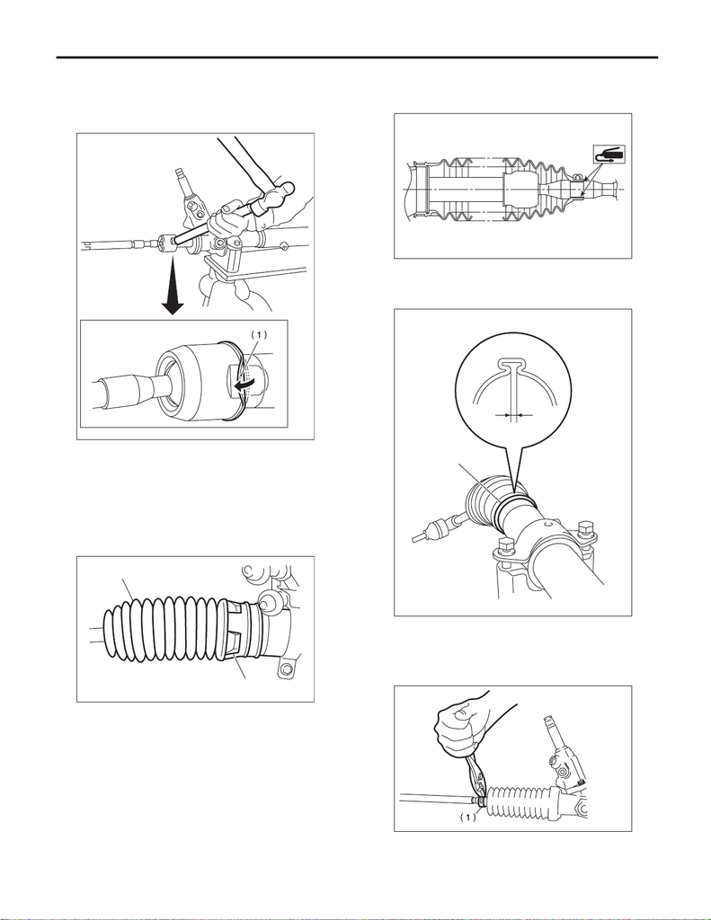

PS-44

Steering Gearbox

POWER ASSISTED SYSTEM (POWER STEERING)

34) Bend the lock washer and crimp it.

CAUTION:

Be careful not to scratch the rack when crimp-

ing lock washer.

35) Apply a coat of grease to the tie-rod groove,

and then install the boot to the housing.

CAUTION:

Right side boot has groove for identification, be

sure to install the right and left of boot.

NOTE:

Make sure that the boot is installed without unusual

inflation or deflation.

36) Install a new boot band. Using band clamp pli-

ers, crimp it so that the clearance of crimping por-

tion becomes 2 mm (0.079 in) or less.

37) Fix the boot end with small clip.

(1) Lock washer

(1) Right side boot

(2) Groove for identification

PS-00093

PS-00524

(2)

(1)

(A) Boot band

(B) 2 mm (0.079 in) or less

(1) Clip

PS-00194

PS-00499

(A)

(B)

PS-00053

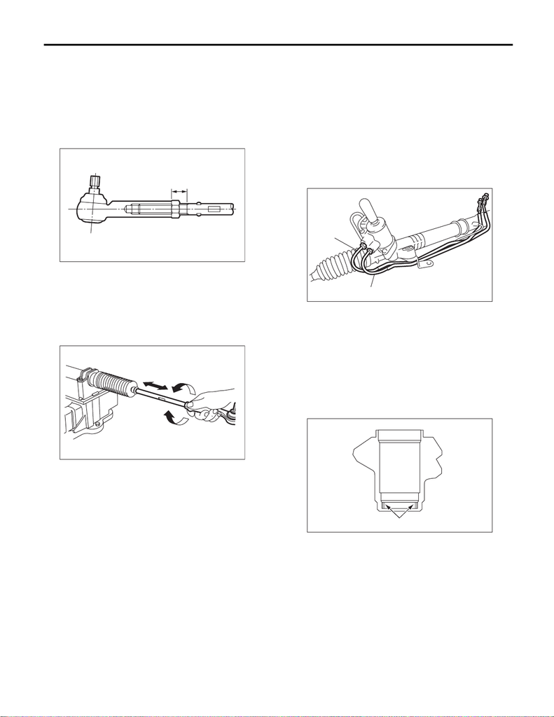

PS-45

Steering Gearbox

POWER ASSISTED SYSTEM (POWER STEERING)

38) After installing, check that the boot end is in-

stalled to the groove of the tie-rod.

39) If the tie-rod end has been removed, screw in

lock nut and tie-rod end to the screwed portion of

tie-rod, and tighten the lock nut temporarily in a po-

sition as shown in the figure.

Installed tie-rod length L:

28 mm (1.1 in)

40) Inspect the gearbox as follows:

“A” Holding the tie-rod end, repeat lock to lock sev-

eral times as quickly as possible.

“B” Holding the tie-rod end, turn it slowly at a radius

several times as large as possible.

Finally, make sure that the boot is installed in the

specified position without inflating.

41) Remove the gearbox from ST.

Preparation tool:

ST1: STAND (926200000)

ST2: BOSS D (34199AG000)

42) Install the four pipes on gearbox.

(1) Connect the pipes A and B to the four pipe

joints of gearbox.

Tightening torque:

Cylinder side: 27 N·m (2.8 kgf-m, 19.9 ft-lb)

Gear housing side: 17 N·m (1.7 kgf-m, 12.5 ft-lb)

(2) Connect the feed pipe and return pipe to the

gearbox.

Tightening torque:

Feed pipe: 37 N·m (3.8 kgf-m, 27.3 ft-lb)

Return pipe: 29 N·m (3.0 kgf-m, 21.4 ft-lb)

2. CONTROL VALVE ASSEMBLY

Specified steering grease:

VALIANT GREASE M2

1) Clean all parts and tools before reassembling.

2) Apply a coat of specified power steering fluid to

the inner wall of valve housing.

3) Apply grease to the oil seal.

4) Verify the direction of oil seal.

L

PS-00097

B

A

PS-00098

(1) Feed pipe

(2) Return pipe

(1) Apply fluid.

PS-00525

(1)

(2)

PS-00169

(1)

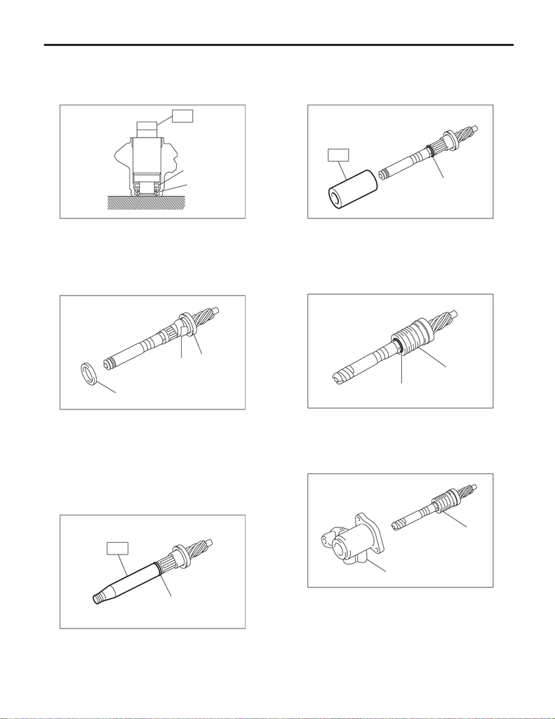

PS-46

Steering Gearbox

POWER ASSISTED SYSTEM (POWER STEERING)

5) Using the ST and a press, install the oil seal and

the bushing in valve housing.

Preparation tool:

ST: INSTALLER & REMOVER (34199AG090)

6) Apply vinyl tape to the groove of pinion.

7) Install the wave washer and oil seal to pinion,

and then remove the vinyl tape.

8) Attach the ST to pinion, and install the seal ring

and O-ring.

Preparation tool:

ST: GUIDE (34199AG020)

9) Remove the ST GUIDE, and form the seal ring

properly using ST FORMER.

Preparation tool:

ST: FORMER (34199AG070)

10) Put vinyl tape around pinion shaft spline to pro-

tect oil seal from damage.

11) Install the valve to pinion, and install the snap

ring.

12) Attach the pinion & valve assembly into the

valve housing.

(1) Bushing

(2) Oil seal

(1) Oil seal

(2) Vinyl tape

(3) Wave washer

(1) Seal ring and O-ring

PS-00856

(2)

(1)

ST

PS-00528

(1)

(2)

(3)

PS-00529

(1)

ST

(1) Seal ring

(1) Snap ring

(2) Valve

(1) Valve housing

(2) Pinion & valve ASSY

PS-00530

ST

(1)

PS-00531

(2)

(1)

PS-00532

(1)

(2)

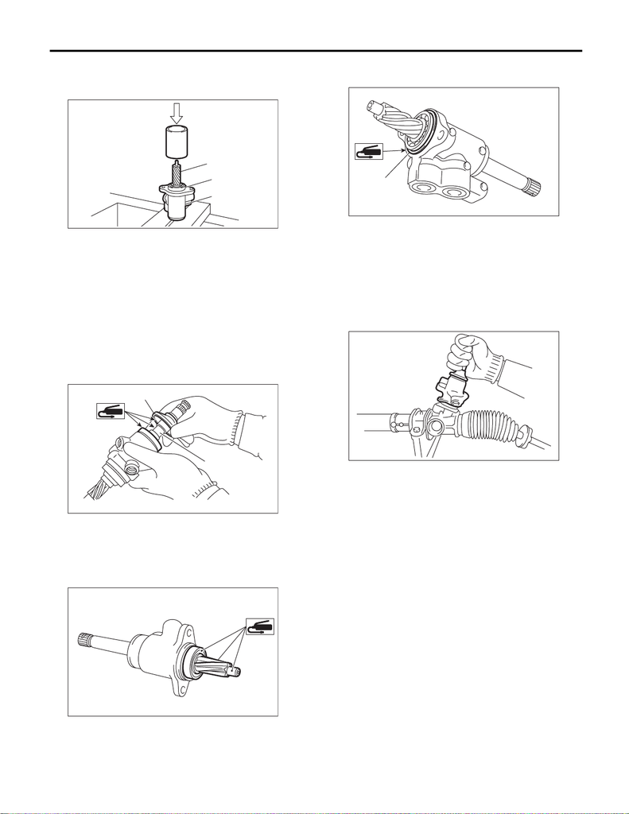

PS-47

Steering Gearbox

POWER ASSISTED SYSTEM (POWER STEERING)

13) Using a press, push the outer race of bearing

and press-fit the pinion & valve assembly into hous-

ing.

14) Apply the specified grease to the dust cover

and fill it to the clearance between pinion shaft and

housing.

15) Install the dust cover on valve assembly.

CAUTION:

Be sure to install the dust cover to groove of

shaft.

16) Apply the genuine grease to the edge and body

of pinion gear and bearing of valve assembly.

17) Apply grease to a new O-ring and attach it to

the valve assembly.

18) Insert the valve assembly into the given place

while facing the rack teeth toward pinion.

CAUTION:

Check that the needle bearing is not damaged.

Replace with a new steering gearbox if damage

is found.

19) Tighten the bolts alternately to secure the valve

assembly.

CAUTION:

Be sure to alternately tighten the bolts.

Tightening torque:

20 N·m (2.0 kgf-m, 14.8 ft-lb)

20) Apply liquid gasket to 1/3 or more of entire pe-

rimeter of adjusting screw thread.

Liquid gasket:

THREE BOND 1102

(1) Pinion & valve ASSY

(2) Bearing

(3) Housing

(1) Dust cover

(2) Groove

PS-00533

(1)

(2)

(3)

PS-01675

(1)

(2)

PS-01674

(1) O-ring

PS-01676

(1)

PS-00143

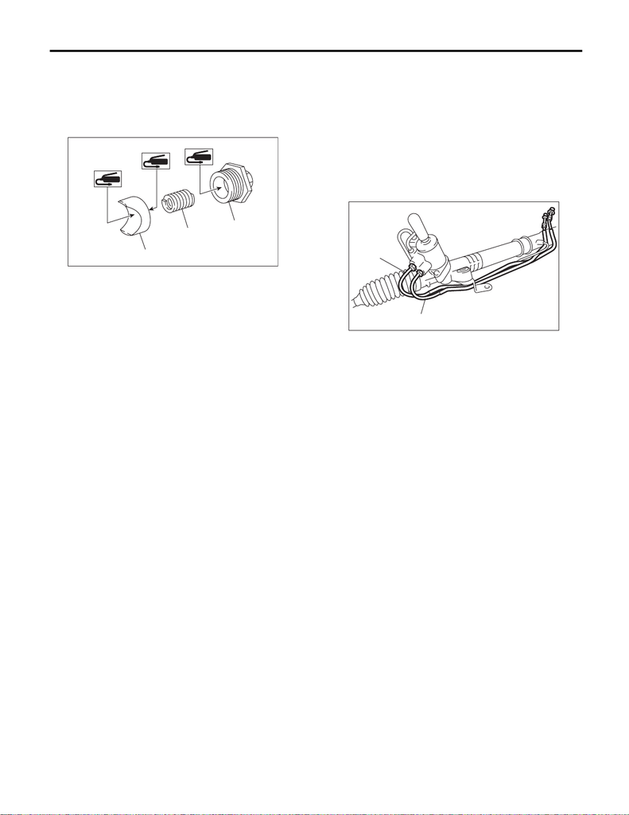

PS-48

Steering Gearbox

POWER ASSISTED SYSTEM (POWER STEERING)

21) Apply a coat of grease to the sliding surface of

sleeve and seating surface of spring, and then in-

sert the sleeve into steering body.

Charge the adjusting screw with grease, and then

insert the spring into adjusting screw. Then install

on the steering body.

22) Tighten the adjusting screw to the specified

torque, then loosen it.

Tightening torque:

25 N·m (2.5 kgf-m, 18.4 ft-lb)

23) Tighten the adjusting screw to the specified

torque, then loosen it 5°.

Tightening torque:

5.9 N·m (0.6 kgf-m, 4.4 ft-lb)

24) Adjust the turning resistance of gearbox so that

it is within specification using adjusting screw.

<Ref. to PS-50, LIMIT, INSPECTION, Steering

Gearbox.>

25) Attach the lock nut into adjusting screw, and

while holding the adjusting screw with wrench,

tighten the lock nut using ST.

Preparation tool:

ST: SPANNER (926230000)

Tightening torque (lock nut):

25 N·m (2.5 kgf-m, 18.4 ft-lb)

NOTE:

Hold the adjusting screw with a wrench to prevent it

from turning while tightening lock nut.

26) Remove the gearbox from ST.

Preparation tool:

ST1: STAND (926200000)

ST2: BOSS D (34199AG000)

27) Install the four pipes on gearbox.

(1) Connect the pipes A and B to gearbox.

Tightening torque:

Cylinder side: 27 N·m (2.8 kgf-m, 19.9 ft-lb)

Gear housing side: 17 N·m (1.7 kgf-m, 12.5 ft-lb)

(2) Connect the feed pipe and return pipe to the

gearbox.

Tightening torque:

Feed pipe: 37 N·m (3.8 kgf-m, 27.3 ft-lb)

Return pipe: 29 N·m (3.0 kgf-m, 21.4 ft-lb)

(1) Sleeve

(2) Spring

(3) Adjusting screw

(2)

(1)

(3)

PS-00167

(1) Feed pipe

(2) Return pipe

PS-00525

(1)

(2)

[figure not shown]

PS-49

Steering Gearbox

POWER ASSISTED SYSTEM (POWER STEERING)

E: INSPECTION

1. BASIC INSPECTION

1) Clean all the disassembled parts, and check for wear, damage or any other faults, then repair or replace

as necessary.

2) When disassembling, check the inside of gearbox for water. If any water is found, carefully check the boot

for damage, input shaft dust seal, adjusting screw and boot clips for poor sealing. If faulty, replace with new

parts.

No. Parts Inspection Corrective action

1 Input shaft

(1) Bent input shaft

(2) Damage on serration

If the bend or damage is excessive, replace the entire

gearbox.

2 Dust seal

(1) Crack or damage

(2) Wear

If the outer wall slips, the lip is worn out or damage is

found, replace it with a new part.

3 Rack and pinion Poor mating of rack with pinion

(1) Adjust the backlash properly.

By measuring the turning torque of the gearbox and slid-

ing resistance of rack, check if the rack & pinion engage

uniformly and smoothly with each other. (Refer to “Ser-

vice limit”.)

(2) Pull out the entire rack to allow viewing of the teeth,

and check for damage.

When abnormality is found in either (1) or (2), replace the

entire gearbox.

4 Gearbox unit

(1) Bending of the rack shaft

(2) Bending of the cylinder portion

(3) Crack or damage on the alumi-

num portion

Replace the gearbox with a new part.

(4) Wear or damage on rack bush-

ing

If the free play of rack shaft in radial direction is out of the

specified range, replace the gearbox with new part.

(Refer to “Service limit”.)

(5) Wear on input shaft bearing

If the free play of input shaft in radial and axial direction is

out of the specified range, replace the gearbox with a new

part. (Refer to “Service limit”.)

5 Boot Crack, damage or deterioration Replace.

6 Tie-rod

(1) Looseness of ball joint

(2) Bend of tie-rod

Replace.

7 Tie-rod end

Damage or deterioration of dust

seal

Replace.

8

Adjusting screw

spring

Deterioration Replace.

9 Boot clip Deterioration Replace.

10 Sleeve Damage Replace.

11 Pipe

(1) Damage to flared surface

(2) Damage to flare nut

(3) Damage to pipe

Replace.

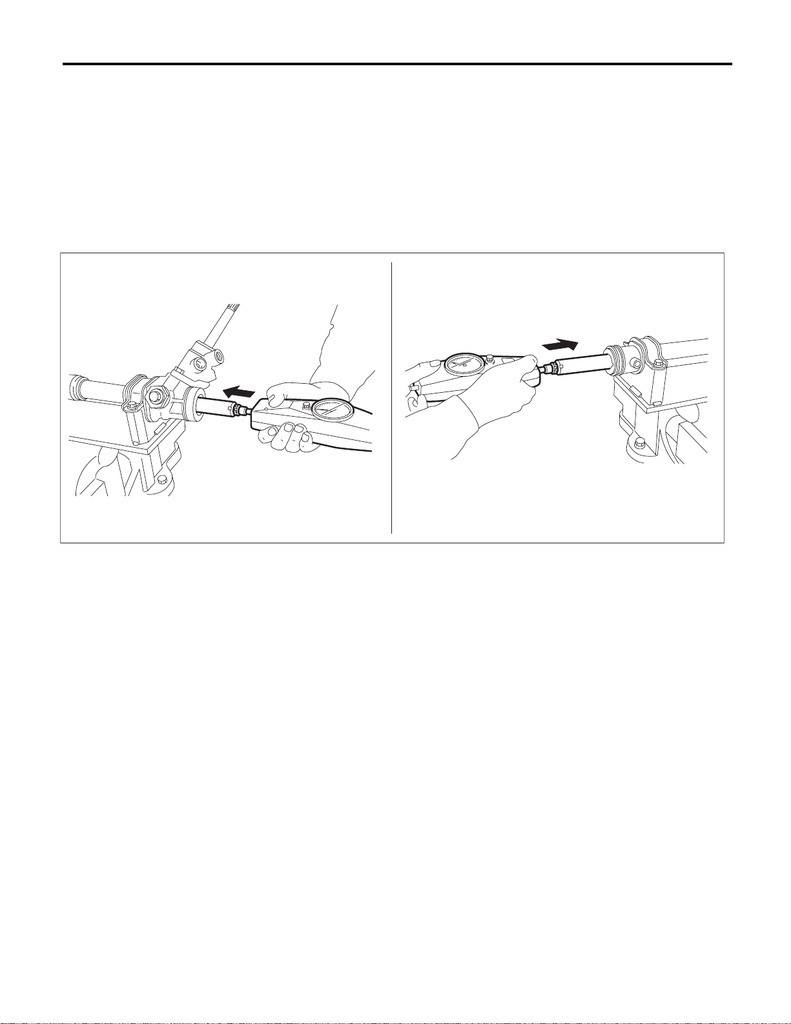

PS-50

Steering Gearbox

POWER ASSISTED SYSTEM (POWER STEERING)

2. LIMIT

Make a measurements as follows. If it exceeds the specified service limits, adjust or replace.

CAUTION:

• When making a measurement, secure the gearbox in a vise using ST.

• When fixing the gearbox in a vise, apply a wooden piece on the flange portion.

Preparation tool:

ST1: STAND (926200000)

ST2: BOSS D (34199AG000)

Rack shaft sliding resistance

Limit: 343 N (35.0 kgf, 77 lbf) or less

Left/right differential of sliding resistance: 20% or less

PS-01186

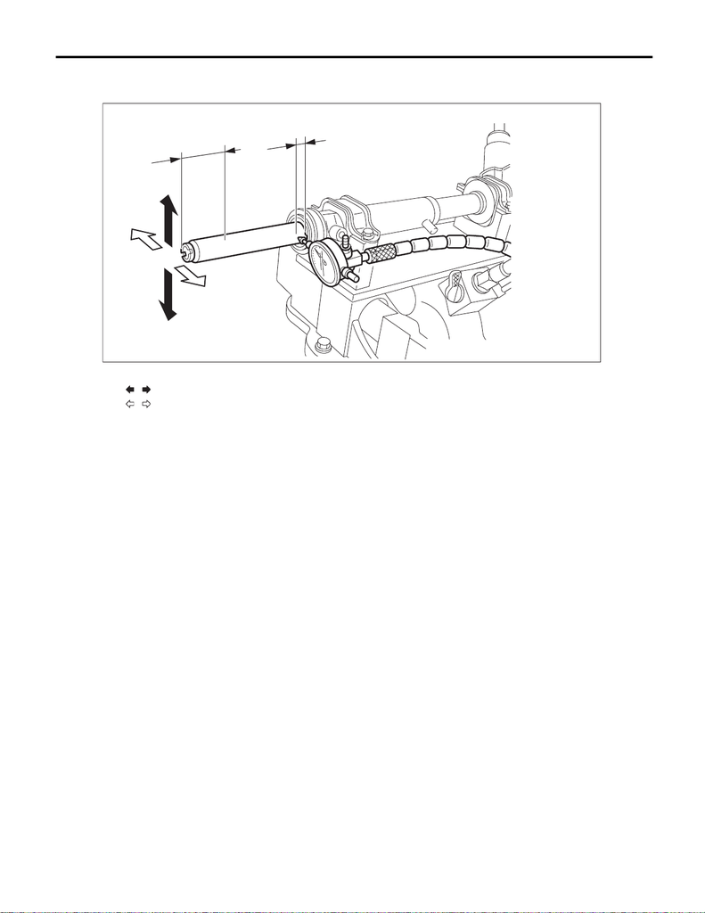

PS-51

Steering Gearbox

POWER ASSISTED SYSTEM (POWER STEERING)

Rack shaft play in the radial direction

• Right-turn steering

Limit

Condition

Weighting point

L1: 10 mm (0.39 in)

P: 98 N (10 kgf, 22 lb)

Measuring point

L2: 5 mm (0.2 in)

PS-01752

P

L2

L1

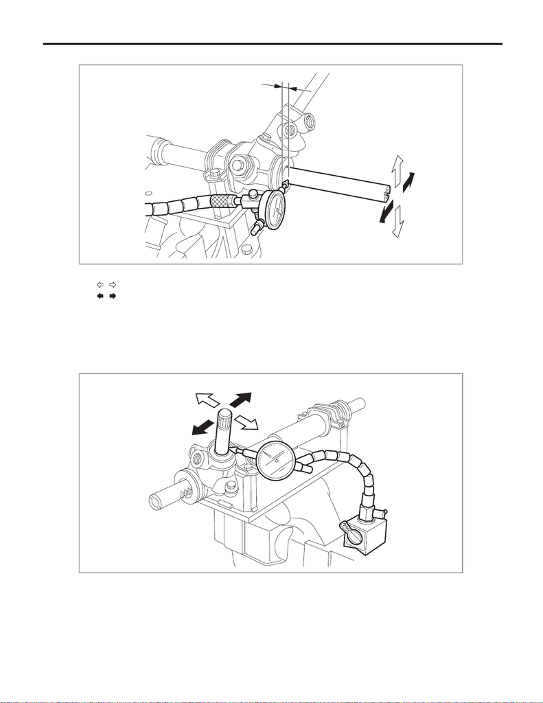

PS-52

Steering Gearbox

POWER ASSISTED SYSTEM (POWER STEERING)

• Left-turn steering

Service limit:

Condition

L: 5 mm (0.20 in)

P: 98 N (10 kgf, 22 lbf)

Input shaft play

• In radial direction

Limit

0.26 mm (0.0102 in) or less

Condition

P: 98 N (10 kgf, 22 lbf)

PS-01188

L

P

PS-01189

P

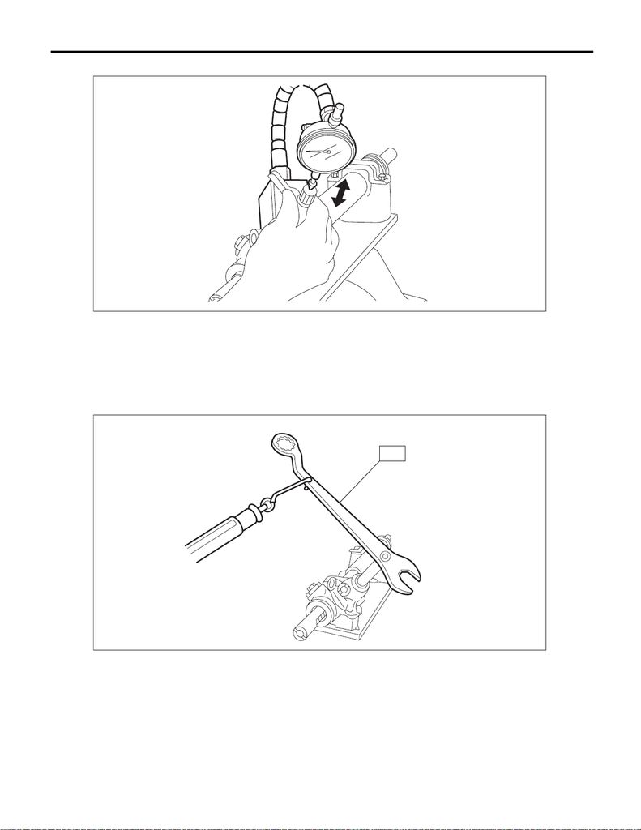

PS-53

Steering Gearbox

POWER ASSISTED SYSTEM (POWER STEERING)

• In axial direction

Limit

Without play

Rotational resistance of gearbox

Using the ST, measure the gearbox turning resistance.

Preparation tool:

ST: SPANNER (34099PA100)

Service limit:

Maximum allowable resistance: 21 N (2.14 kgf, 4.7 lbf) or less

Difference between right and left rotational resistance: 20% or less

PS-01753

PS-01191

ST

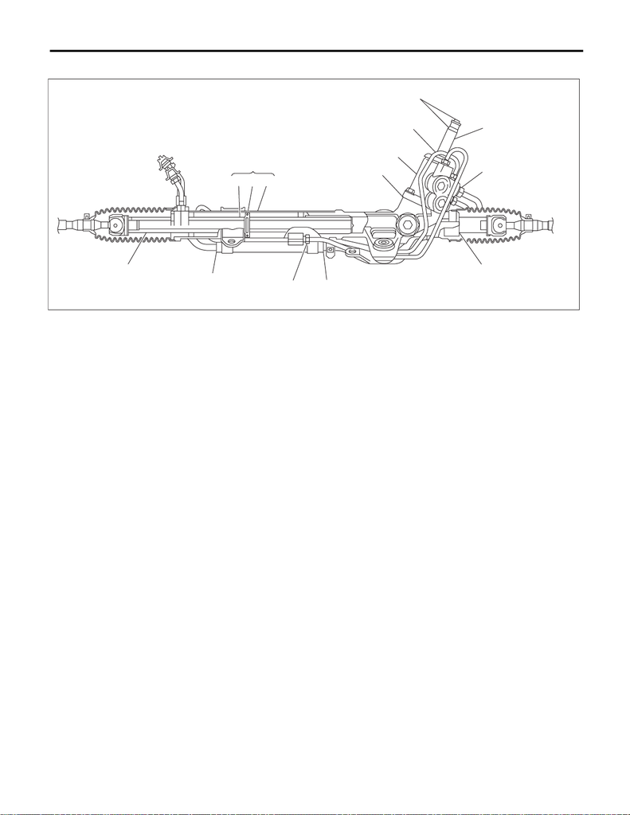

PS-54

Steering Gearbox

POWER ASSISTED SYSTEM (POWER STEERING)

3. FLUID LEAKAGE

1) Lift up the vehicle.

2) If a fluid leak is found, clean the fluid completely from the suspect area, and turn the steering wheel 30 to

40 times to the left and right from lock to lock, with the engine running, and check again for leaks immediately,

and also after a few hours have passed.

3) Cause and solution for oil leakage from “a”

The oil seal is damaged. Replace the valve assembly or valve housing side oil seal assembly with a new part.

4) Cause and solution for oil leakage from “b”

The torsion bar O-ring is damaged. Replace the valve assembly with a new part.

5) Cause and solution for oil leakage from “c”

The oil seal is damaged. Replace the valve assembly or pinion side oil seal with a new part.

6) Cause and solution for oil leakage from “d”

The pipe is damaged. Replace the faulty pipe or O-ring.

7) Cause and solution for oil leakage from “g”

The hose is damaged. Replace the hose with a new part.

8) If leak is other than a, b, c, d or g, or if oil is leaking from gearbox, move the right and left boots toward tie-

rod end side, respectively, with the gearbox mounted to the vehicle, and remove fluid from surrounding por-

tions. Then, turn the steering wheel from lock to lock about 30 to 40 times with the engine running, then re-

inspect the leaking area immediately after and several hours after this operation.

(1) Leakage from “e”

The cylinder seal is damaged. Replace the oil seal.

(2) Leakage from “f”

There are two possible causes. Perform the following step first. Remove the pipe assembly B from the

valve housing, and close the circuit using ST.

Preparation tool:

ST: PLUG (926420000)

Turn the steering wheel from lock to lock approx. 30 to 40 times with the engine running, then inspect the

leaked portion immediately after and several hours after this operation.

• If leakage from “f” is noted again:

The oil seal of pinion and valve assembly is damaged. Replace the pinion & valve assembly with a new part.

Or, replace the oil seal.

• If oil stops leaking from “f”:

The oil seal of rack housing is damaged. Replace the oil seal and back-up ring.

(1) Power cylinder (3) Rack piston (5) Input shaft

(2) Cylinder (4) Rack axle (6) Valve housing

PS-00622

(4) (3) (2)

(5)

(6)

c

d

a

b

(1)

f

g

g

d

e

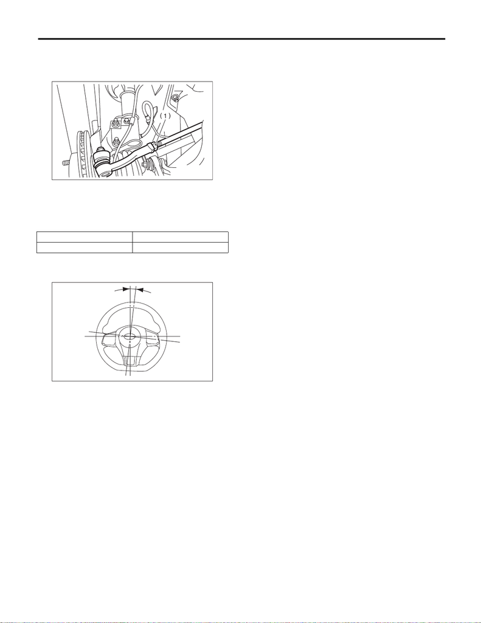

PS-55

Steering Gearbox

POWER ASSISTED SYSTEM (POWER STEERING)

F: ADJUSTMENT

1) Adjust the front toe.

<Ref. to FS-13, FRONT WHEEL TOE-IN, INSPECTION, Wheel Alignment.>

2) Check the steering angle of the wheels.

Standard of steering angle:

3) If the steering wheel spokes are not horizontal when wheels are set in the straight ahead position, or error

is more than 5° on the periphery of the steering wheel, correctly re-install the steering wheel.

4) If the steering wheel spokes are not horizontal with vehicle set in the straight ahead position after this ad-

justment, correct it by turning the right and left tie-rods in the opposite direction from each other by the same

angle.

PS-00107

(1) Lock nut

Inner wheel Outer wheel

36.3°±1.5° 32.0°±1.5°

(1)

PS-01734

(1) 5° or less